# INSIGHTS FROM THE 2015 WORLD HAPPINESS DATA

LATIF KADIR

## Overview of the project

This project was intended to analyze the world happiness data and produce a report to inform policy making. This objective was achieved by extracting, cleaning, wrangling, analyzing, and interpreting the results from the data.

## Questions to be addressed

This project is designed to address the following questions:

1. What is the relationship between Freedom and Happiness score?
2. What is the relationship between corruption and Happiness score?
3. What is the relationship between Life expectancy and Happiness score?
4. What is the average happiness score per region?
5. What is the effect of the predictors on the outcome variable, happiness.

The stakeholders include public policy makers as well as various government officials.

## Tools for the analysis

The dataset for the analysis was sourced from World Happiness Report. The dataset is stored in Kaggle. The analysis was based on the data for the year 2015. The happiness scores and ranking use data from the Gallup World Pool. RStudio will be used to analyse the data because of the following reasons:

- With a given dataset, any analysis made with R can be reproduced at any point in time by the managers or any other person interested in verifying the authenticity of the results.
- R comes with several packages which aid in all aspects of analysis ranging from descriptive analysis, inferential analysis, as well as making visualization.
- Moreover, R software is suitable for handling large datasets.

## Load libraries

```r
## Load the data
library(tidyverse)
library(dplyr)
library(haven)
library(psych)
library(nlme)
library(plm)
```

## Performing ETL

```r
## Load the data
happiness_data<- read.csv("2015.csv")

## Summary statistics
str(happiness_data) ## structure of the data
```

```
## 'data.frame':    158 obs. of  12 variables:
##  $ Country                      : chr  "Switzerland" "Iceland" "Denmark" "Norway" ...
##  $ Region                       : chr  "Western Europe" "Western Europe" "Western Europe" "Western Europe" ...
##  $ Happiness.Rank               : int  1 2 3 4 5 6 7 8 9 10 ...
##  $ Happiness.Score              : num  7.59 7.56 7.53 7.52 7.43 ...
##  $ Standard.Error               : num  0.0341 0.0488 0.0333 0.0388 0.0355 ...
##  $ Economy..GDP.per.Capita.     : num  1.4 1.3 1.33 1.46 1.33 ...
##  $ Family                       : num  1.35 1.4 1.36 1.33 1.32 ...
##  $ Health..Life.Expectancy.     : num  0.941 0.948 0.875 0.885 0.906 ...
##  $ Freedom                      : num  0.666 0.629 0.649 0.67 0.633 ...
##  $ Trust..Government.Corruption.: num  0.42 0.141 0.484 0.365 0.33 ...
##  $ Generosity                   : num  0.297 0.436 0.341 0.347 0.458 ...
##  $ Dystopia.Residual            : num  2.52 2.7 2.49 2.47 2.45 ...
```

```r
summary(happiness_data) ## summary of the data
```

```
##    Country             Region          Happiness.Rank   Happiness.Score
##  Length:158         Length:158         Min.   :  1.00   Min.   :2.839
##  Class :character   Class :character   1st Qu.: 40.25   1st Qu.:4.526
##  Mode  :character   Mode  :character   Median : 79.50   Median :5.232
##                                        Mean   : 79.49   Mean   :5.376
##                                        3rd Qu.:118.75   3rd Qu.:6.244
##                                        Max.   :158.00   Max.   :7.587
##  Standard.Error    Economy..GDP.per.Capita.     Family
##  Min.   :0.01848   Min.   :0.0000           Min.   :0.0000
##  1st Qu.:0.03727   1st Qu.:0.5458           1st Qu.:0.8568
##  Median :0.04394   Median :0.9102           Median :1.0295
##  Mean   :0.04788   Mean   :0.8461           Mean   :0.9910
##  3rd Qu.:0.05230   3rd Qu.:1.1584           3rd Qu.:1.2144
##  Max.   :0.13693   Max.   :1.6904           Max.   :1.4022
##  Health..Life.Expectancy.    Freedom       Trust..Government.Corruption.
##  Min.   :0.0000           Min.   :0.0000   Min.   :0.00000
##  1st Qu.:0.4392           1st Qu.:0.3283   1st Qu.:0.06168
##  Median :0.6967           Median :0.4355   Median :0.10722
##  Mean   :0.6303           Mean   :0.4286   Mean   :0.14342
##  3rd Qu.:0.8110           3rd Qu.:0.5491   3rd Qu.:0.18025
##  Max.   :1.0252           Max.   :0.6697   Max.   :0.55191
##    Generosity     Dystopia.Residual
##  Min.   :0.0000   Min.   :0.3286
##  1st Qu.:0.1506   1st Qu.:1.7594
##  Median :0.2161   Median :2.0954
##  Mean   :0.2373   Mean   :2.0990
##  3rd Qu.:0.3099   3rd Qu.:2.4624
##  Max.   :0.7959   Max.   :3.6021
```

```r
sum(is.na(happiness_data)) ## checking total missing values
```

```
## [1] 0
```

```r
describe(happiness_data[, c(4,6:11)]) ## descriptives of the numeric variables
```

|  | vars | n | mean | sd | median | trimmed | mad | min | max | range | skew | kurtosis | se |
| --- | --- | --- | --- | --- | --- | --- | --- | --- | --- | --- | --- | --- | --- |
| Happiness.Score | 1 | 158 | 5.3757342 | 1.1450101 | 5.232500 | 5.3633984 | 1.13641290 | 2.839 | 7.58700 | 4.74800 | 0.09592055 | -0.8173610 | 0.091092115 |
| Economy..GDP.per.Capita. | 2 | 158 | 0.8461372 | 0.4031208 | 0.910245 | 0.8611404 | 0.45453551 | 0.000 | 1.69042 | 1.69042 | -0.31157020 | -0.9043097 | 0.032070567 |
| Family | 3 | 158 | 0.9910459 | 0.2723691 | 1.029510 | 1.0212899 | 0.26465893 | 0.000 | 1.40223 | 1.40223 | -0.98785557 | 0.8036544 | 0.021668521 |
| Health..Life.Expectancy. | 4 | 158 | 0.6302594 | 0.2470778 | 0.696705 | 0.6511272 | 0.23700102 | 0.000 | 1.02525 | 1.02525 | -0.69199268 | -0.4518781 | 0.019656452 |
| Freedom | 5 | 158 | 0.4286149 | 0.1506928 | 0.435515 | 0.4363805 | 0.16673320 | 0.000 | 0.66973 | 0.66973 | -0.40564455 | -0.5158078 | 0.011988474 |
| Trust..Government.Corruption. | 6 | 158 | 0.1434218 | 0.1200341 | 0.107220 | 0.1252850 | 0.07791804 | 0.000 | 0.55191 | 0.55191 | 1.35926734 | 1.2493111 | 0.009549398 |
| Generosity | 7 | 158 | 0.2372955 | 0.1266849 | 0.216130 | 0.2266864 | 0.11418985 | 0.000 | 0.79588 | 0.79588 | 0.98301628 | 1.5952844 | 0.010078512 |

```r
## checking distinct countries and Regions
n_distinct(happiness_data$Region) ## 10 regions
```

```
## [1] 10
```

```r
n_distinct(happiness_data$Country) ## 158 countries
```

```
## [1] 158
```

```r
## Plotting total number of countries in each Region
count_in_Reg <- happiness_data |>
                    group_by(Region) |>
                    summarise(total_countries = n()) |>
                    arrange(desc(total_countries))

count_in_Reg
```

| Region | total_countries |
| --- | --- |
| Sub-Saharan Africa | 40 |
| Central and Eastern Europe | 29 |
| Latin America and Caribbean | 22 |
| Western Europe | 21 |
| Middle East and Northern Africa | 20 |
| Southeastern Asia | 9 |
| Southern Asia | 7 |
| Eastern Asia | 6 |
| Australia and New Zealand | 2 |
| North America | 2 |

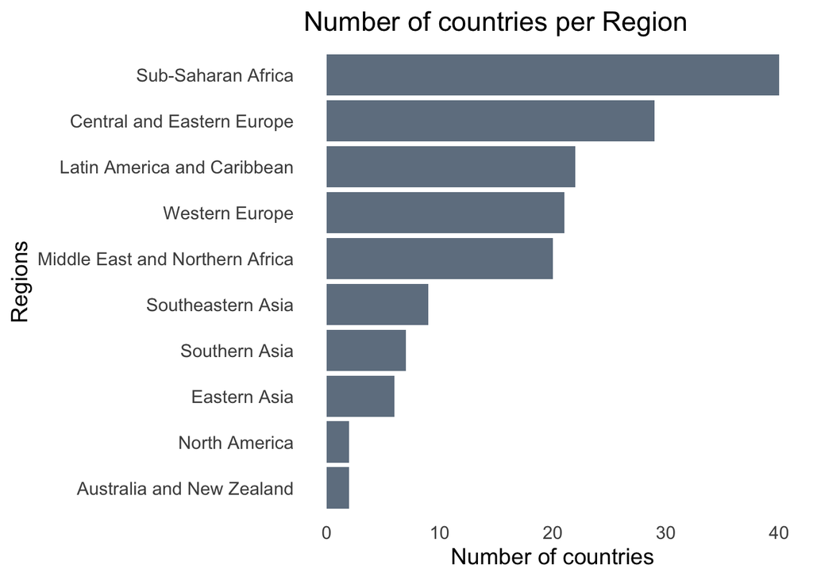

```r
## Plot the total number of countries in each Region
ggplot(data = count_in_Reg, aes(x = reorder(Region, total_countries),
             y = total_countries)) +
  geom_bar(stat = "identity", fill = "#708090") +
  coord_flip() +
  labs(x = "Regions",
       y = "Number of countries",
       title = "Number of countries per Region") +
  theme_minimal(base_size = 14) +
  theme(
    panel.grid.major = element_blank(),
    panel.grid.minor = element_blank()
  )
```

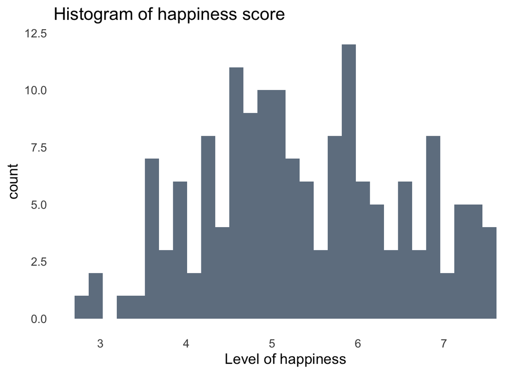

```r
## create an ID for the regions (to serve as cluster ID)
happiness_data <- happiness_data |>
  mutate(region_id = case_when(
    Region == "Australia and New Zealand" ~ 1,
    Region == "Central and Eastern Europe" ~ 2,
    Region == "Eastern Asia" ~ 3,
    Region == "Latin America and Caribbean" ~ 4,
    Region == "Middle East and Northern Africa" ~ 5,
    Region == "North America" ~ 6,
    Region == "Southeastern Asia" ~ 7,
    Region == "Southern Asia" ~ 8,
    Region == "Sub-Saharan Africa" ~ 9,
    Region == "Western Europe"~ 10
  ))


## Histogram of the outcome variable
happiness_data |>
  ggplot(aes(x = Happiness.Score)) +
  geom_histogram(fill = "#708090") +
  labs(title = "Histogram of happiness score",
       x = "Level of happiness") +
  theme_minimal(base_size = 14) +
  theme(
    panel.grid.major = element_blank(),
    panel.grid.minor = element_blank()
  )
```

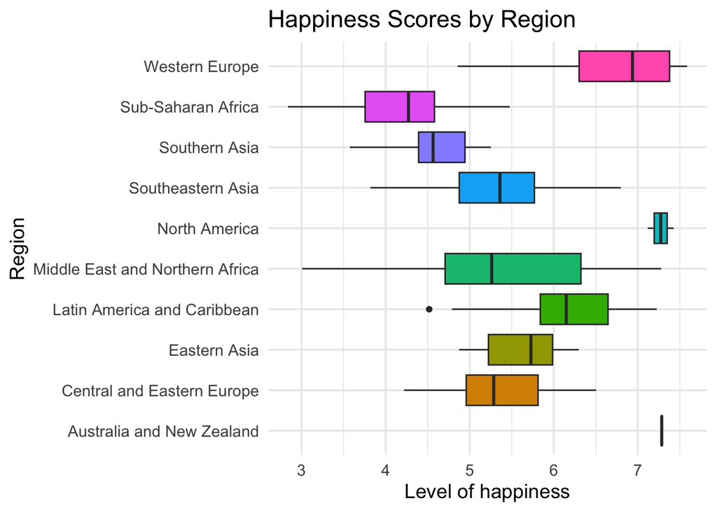

```r
## Boxplot of happiness score by regions
happiness_data |>
  ggplot(aes(x = Happiness.Score, y = Region, fill = Region)) +
  geom_boxplot() +
  labs(
    title = "Happiness Scores by Region",
    x = "Level of happiness",
    y = "Region"
  ) +
  theme_minimal(base_size = 14) +
  theme(legend.position = "none") ## no legend is needed
```

- The bar graph and the `count_in_Reg` data, it could be observed that the region with the highest number of countries is *Sub-Saharan Africa*, and the region with the lowest number of countries in the data is *Australia and New Zealand*.
- From the box plot, it appears that *Sub-Saharan African* region has the lowest level happiness, whiles *Australia and New Zealand*, *Western Europe*, and *North America* had the highest level of happiness.

## Checking the correlation between freedom and happiness score

```r
cor(happiness_data$Happiness.Score, happiness_data$Freedom) ## 0.5682
```

```
## [1] 0.5682109
```

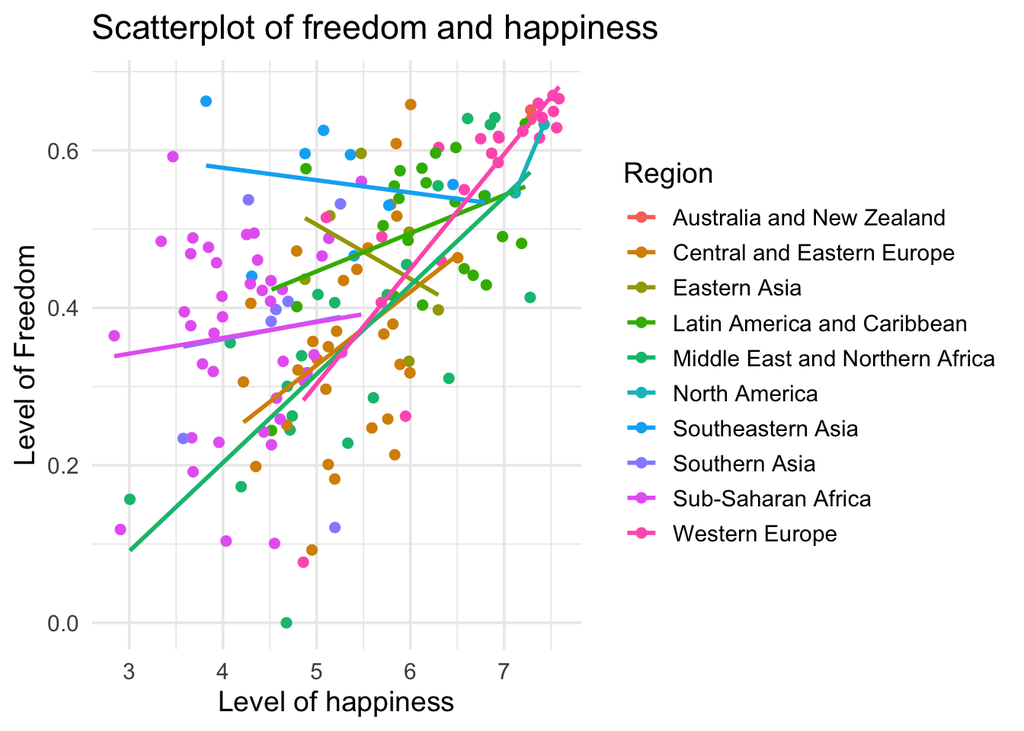

```r
happiness_data |>
  ggplot(aes(x=Happiness.Score,y=Freedom, color=Region)) +
  geom_point(size=2)+
  geom_smooth(method = "lm", se = FALSE) +
  labs(title = "Scatterplot of freedom and happiness",
       x= "Level of happiness",
       y= "Level of Freedom") +
  theme_minimal(base_size = 14)
```

## Checking the correlation between Corruption and Happiness score

```r
cor(happiness_data$Happiness.Score,happiness_data$Trust..Government.Corruption.) ## 0.3952
```

```
## [1] 0.3951986
```

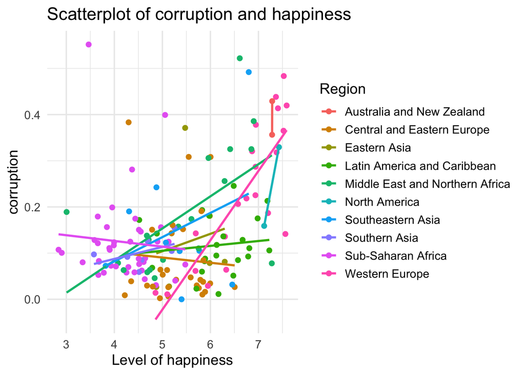

```r
happiness_data |>
  ggplot(aes(x= Happiness.Score, y=Trust..Government.Corruption., color=Region)) +
  geom_point(size=2)+
  geom_smooth(method = "lm", se = FALSE) +
  labs(title = "Scatterplot of corruption and happiness",
       x = "Level of happiness",
       y = "corruption") +
  theme_minimal(base_size = 14)
```

From the scatter plot above, it appears that there exists a weak correlation between corruption and happiness. The correlation coefficient of 0.3952 for the entire dataset indicates a weak positive correlation between corruption and happiness.

## Checking the correlation between Life Expectancy and Happiness score

```r
cor(happiness_data$Happiness.Score,happiness_data$Health..Life.Expectancy.) ## 0.7242
```

```
## [1] 0.7241996
```

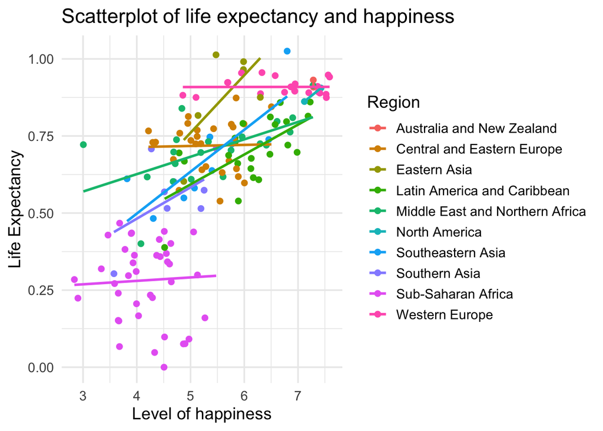

```r
happiness_data |>
  ggplot(aes(x= Happiness.Score, y=Health..Life.Expectancy., color=Region)) +
  geom_point(size=2)+
  geom_smooth(method = "lm", se = FALSE) +
  labs(title = "Scatterplot of life expectancy and happiness",
       x = "Level of happiness",
       y = "Life Expectancy") +
  theme_minimal(base_size = 14)
```

From the scatter plot above, it appears that there exists a strong positive correlation between Life expectancy and Happiness score. That is, the higher the life expectancy rate, the higher the happiness score. This is supported by a high correlation coefficient of 0.7242.

## Graph of level of happiness by Regions

```r
Happiness_by_Region <- happiness_data |>
  group_by(Region) |>
  summarise(Avg_Happiness_Score=mean(Happiness.Score))|>
  arrange(desc(Avg_Happiness_Score))
Happiness_by_Region
```

| Region | Avg_Happiness_Score |
| --- | --- |
| Australia and New Zealand | 7.285000 |
| North America | 7.273000 |
| Western Europe | 6.689619 |
| Latin America and Caribbean | 6.144682 |
| Eastern Asia | 5.626167 |
| Middle East and Northern Africa | 5.406900 |
| Central and Eastern Europe | 5.332931 |
| Southeastern Asia | 5.317444 |
| Southern Asia | 4.580857 |
| Sub-Saharan Africa | 4.202800 |

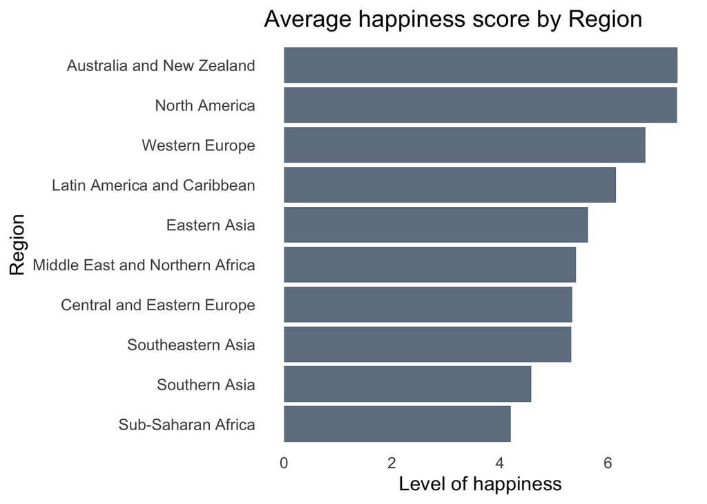

```r
ggplot(data = Happiness_by_Region, aes(x = reorder(Region, Avg_Happiness_Score),
             y = Avg_Happiness_Score)) +
  geom_bar(stat = "identity", fill = "#708090") +
  coord_flip() +
  labs(x ="Region",
       y = "Level of happiness",
       title = "Average happiness score by Region") +
  theme_minimal(base_size = 14) +
  theme(
    panel.grid.major = element_blank(),
    panel.grid.minor = element_blank()
  )
```

From the graph above, it could be seen that the region with the highest the highest average happiness score is “Australia and New Zealand” while the region with the lowest average happiness score is “Sub-Saharan Africa”.

## Running an Ordinary Least Square Regression for the model

```r
## simple regression
model1 <- lm(formula = Happiness.Score~Economy..GDP.per.Capita. + Freedom + Family + Health..Life.Expectancy. + Generosity + Trust..Government.Corruption., data=happiness_data)
summary(model1)
```

```
##
## Call:
## lm(formula = Happiness.Score ~ Economy..GDP.per.Capita. + Freedom +
##     Family + Health..Life.Expectancy. + Generosity + Trust..Government.Corruption.,
##     data = happiness_data)
##
## Residuals:
##      Min       1Q   Median       3Q      Max
## -1.40484 -0.31734 -0.02814  0.37189  1.50130
##
## Coefficients:
##                               Estimate Std. Error t value Pr(>|t|)
## (Intercept)                     1.8602     0.1905   9.766  < 2e-16 ***
## Economy..GDP.per.Capita.        0.8607     0.2203   3.907 0.000141 ***
## Freedom                         1.3334     0.3850   3.463 0.000694 ***
## Family                          1.4089     0.2227   6.327 2.69e-09 ***
## Health..Life.Expectancy.        0.9753     0.3163   3.084 0.002433 **
## Generosity                      0.3889     0.3910   0.995 0.321471
## Trust..Government.Corruption.   0.7845     0.4365   1.797 0.074302 .
## ---
## Signif. codes:  0 '***' 0.001 '**' 0.01 '*' 0.05 '.' 0.1 ' ' 1
##
## Residual standard error: 0.551 on 151 degrees of freedom
## Multiple R-squared:  0.7772, Adjusted R-squared:  0.7684
## F-statistic: 87.81 on 6 and 151 DF,  p-value: < 2.2e-16
```

```r
## Fixed effect model (Region fixed effect)
happiness_data <- happiness_data |>
  mutate(Region = as.factor(Region),
         region_id = as.factor(region_id))

model2 <- lm(formula = Happiness.Score~Economy..GDP.per.Capita. + Freedom + Family + Health..Life.Expectancy. + Generosity + Trust..Government.Corruption. + Region, data=happiness_data)
summary(model2)
```

```
##
## Call:
## lm(formula = Happiness.Score ~ Economy..GDP.per.Capita. + Freedom +
##     Family + Health..Life.Expectancy. + Generosity + Trust..Government.Corruption. +
##     Region, data = happiness_data)
##
## Residuals:
##      Min       1Q   Median       3Q      Max
## -1.43699 -0.26343 -0.01104  0.29632  1.24909
##
## Coefficients:
##                                       Estimate Std. Error t value Pr(>|t|)
## (Intercept)                            2.87864    0.56746   5.073 1.21e-06 ***
## Economy..GDP.per.Capita.               0.95771    0.22274   4.300 3.16e-05 ***
## Freedom                                0.90377    0.39168   2.307   0.0225 *
## Family                                 1.23995    0.22722   5.457 2.10e-07 ***
## Health..Life.Expectancy.               0.43928    0.42000   1.046   0.2974
## Generosity                             0.37807    0.43048   0.878   0.3813
## Trust..Government.Corruption.          0.96687    0.43847   2.205   0.0291 *
## RegionCentral and Eastern Europe      -0.53492    0.41352  -1.294   0.1979
## RegionEastern Asia                    -0.73105    0.43951  -1.663   0.0985 .
## RegionLatin America and Caribbean      0.09822    0.41045   0.239   0.8112
## RegionMiddle East and Northern Africa -0.51951    0.41164  -1.262   0.2090
## RegionNorth America                    0.17880    0.51794   0.345   0.7304
## RegionSoutheastern Asia               -0.58883    0.42460  -1.387   0.1677
## RegionSouthern Asia                   -0.43794    0.45661  -0.959   0.3391
## RegionSub-Saharan Africa              -0.70158    0.45843  -1.530   0.1281
## RegionWestern Europe                  -0.21368    0.38888  -0.549   0.5835
## ---
## Signif. codes:  0 '***' 0.001 '**' 0.01 '*' 0.05 '.' 0.1 ' ' 1
##
## Residual standard error: 0.5138 on 142 degrees of freedom
## Multiple R-squared:  0.8179, Adjusted R-squared:  0.7987
## F-statistic: 42.52 on 15 and 142 DF,  p-value: < 2.2e-16
```

```r
## using plm for the fixed effect model
model3 <- plm(
  Happiness.Score ~ Economy..GDP.per.Capita. + Freedom + Family +
    Health..Life.Expectancy. + Generosity + Trust..Government.Corruption.,
  data = happiness_data,
  index = "region_id",  ## we can just use index = "Region" and get same results
  model = "within"
)
summary(model3)
```

```
## Oneway (individual) effect Within Model
##
## Call:
## plm(formula = Happiness.Score ~ Economy..GDP.per.Capita. + Freedom +
##     Family + Health..Life.Expectancy. + Generosity + Trust..Government.Corruption.,
##     data = happiness_data, model = "within", index = "region_id")
##
## Unbalanced Panel: n = 10, T = 2-40, N = 158
##
## Residuals:
##      Min.   1st Qu.    Median   3rd Qu.      Max.
## -1.436994 -0.263427 -0.011038  0.296322  1.249088
##
## Coefficients:
##                               Estimate Std. Error t-value  Pr(>|t|)
## Economy..GDP.per.Capita.       0.95771    0.22274  4.2997 3.160e-05 ***
## Freedom                        0.90377    0.39168  2.3074   0.02248 *
## Family                         1.23995    0.22722  5.4570 2.098e-07 ***
## Health..Life.Expectancy.       0.43928    0.42000  1.0459   0.29738
## Generosity                     0.37807    0.43048  0.8783   0.38128
## Trust..Government.Corruption.  0.96687    0.43847  2.2051   0.02905 *
## ---
## Signif. codes:  0 '***' 0.001 '**' 0.01 '*' 0.05 '.' 0.1 ' ' 1
##
## Total Sum of Squares:    82.151
## Residual Sum of Squares: 37.483
## R-Squared:      0.54373
## Adj. R-Squared: 0.49553
## F-statistic: 28.2034 on 6 and 142 DF, p-value: < 2.22e-16
```

```r
## Random intercept model
## First, build intercept-only model to help compute the ICC
model4 <- lme(fixed = Happiness.Score ~ 1,
              random = ~ 1|region_id,
              data = happiness_data)
summary(model4)
```

```
## Linear mixed-effects model fit by REML
##   Data: happiness_data
##        AIC      BIC    logLik
##   390.7357 399.9045 -192.3679
##
## Random effects:
##  Formula: ~1 | region_id
##         (Intercept)  Residual
## StdDev:   0.9630419 0.7459756
##
## Fixed effects:  Happiness.Score ~ 1
##                Value Std.Error  DF  t-value p-value
## (Intercept) 5.727037 0.3177198 148 18.02543       0
##
## Standardized Within-Group Residuals:
##         Min          Q1         Med          Q3         Max
## -3.23096974 -0.56201762  0.06056624  0.67472743  2.49575923
##
## Number of Observations: 158
## Number of Groups: 10
```

```r
# Extract variance components to compute the ICC
var_components <- VarCorr(model4)
var_between <- as.numeric(var_components["(Intercept)", "Variance"])
var_within  <- as.numeric(var_components["Residual", "Variance"])

# Compute ICC
icc <- var_between / (var_between + var_within)
icc                    ## ICC = 0.62
```

```
## [1] 0.6249959
```

```r
## Now, the full multilevel model
model5 <- lme(fixed = Happiness.Score ~ Economy..GDP.per.Capita. + Freedom + Family +
              Health..Life.Expectancy. + Generosity + Trust..Government.Corruption.,
              random = ~ 1|region_id,
              data = happiness_data)
summary(model5)
```

```
## Linear mixed-effects model fit by REML
##   Data: happiness_data
##        AIC     BIC    logLik
##   268.3835 295.539 -125.1917
##
## Random effects:
##  Formula: ~1 | region_id
##         (Intercept)  Residual
## StdDev:   0.2422563 0.5134816
##
## Fixed effects:  Happiness.Score ~ Economy..GDP.per.Capita. + Freedom + Family +      Health..Life.Expectancy. + Generosity + Trust..Government.Corruption.
##                                   Value Std.Error  DF  t-value p-value
## (Intercept)                   2.2213976 0.2753261 142 8.068242  0.0000
## Economy..GDP.per.Capita.      0.9678834 0.2173413 142 4.453289  0.0000
## Freedom                       0.9799559 0.3828643 142 2.559538  0.0115
## Family                        1.2977980 0.2209599 142 5.873455  0.0000
## Health..Life.Expectancy.      0.6372860 0.3714577 142 1.715635  0.0884
## Generosity                    0.4655672 0.4038332 142 1.152870  0.2509
## Trust..Government.Corruption. 0.9736425 0.4279146 142 2.275320  0.0244
##  Correlation:
##                               (Intr) E..GDP Freedm Family H..L.E Gnrsty
## Economy..GDP.per.Capita.       0.100
## Freedom                       -0.202 -0.068
## Family                        -0.369 -0.448 -0.223
## Health..Life.Expectancy.      -0.504 -0.528 -0.028  0.046
## Generosity                    -0.216  0.266 -0.191 -0.112 -0.138
## Trust..Government.Corruption.  0.104 -0.133 -0.399  0.102 -0.033 -0.131
##
## Standardized Within-Group Residuals:
##         Min          Q1         Med          Q3         Max
## -2.72654254 -0.49509189 -0.03470791  0.60845417  2.24470418
##
## Number of Observations: 158
## Number of Groups: 10
```

## Results

The results from the multiple linear regression model, `model1`, showed that GDP per capita, Family, Life expectancy, and Freedom have a positive effect and statistically significant effect on happiness. However, this single level regression model ignores that fact that countries are nested within regions. In other words, this model did not consider the clustering effects. Countries within one region might have some unique common characteristics which distinguishes them from other regions. That is, theoretically, observations from countries within a specific region are expected to be correlated and this has to be taken into account. To address this problem, three different models were considered:

- Region-fixed effect model, `model2`, by manually creating the Region dummy variables. This is same as the linear regression model with the inclusion of the factor, `Region`, as a predictor. We could have also used `region_id` as the factor.
- In `model3`, we used the `plm` package to run the Region fixed effect model. It should be noted that the results from `model2` and `model3` are the same as expected.
- In `model4` and `model5`, we run a multilevel model. `model4` is an intercept-only (i.e., null) model. This model was fitted to help compute the Intra-Class Correlation Coefficient (ICC). The `ICC` was found to be 0.62, indicating that about 62% of the total variance in the outcome variable can be explained by the clusters (i.e., regions). This further confirmed the need for considering the clusters in the analysis. Therefore, `model5`, a random intercept model, was fitted.

## Conclusion

It is therefore recommended that various leaders, especially, governments from the Sub-Sahara African countries should put in much effort to reduce corruption and increase the level of trust of the citizens in the government. Also, policies and programs should be put in place to ensure productivity within the country. This will result in an increase in GDP per-capita subsequently lead to an increase in the level of happiness.